# BANKS_Skills_Test_3.Rmd

2023-11-19

### Welcome

Welcome to my skills test where I will be demonstrating my understanding on how to correctly tidy data, make plots, organize an ANOVA table and create linear models.

### Cleaning and Plotting Salaries

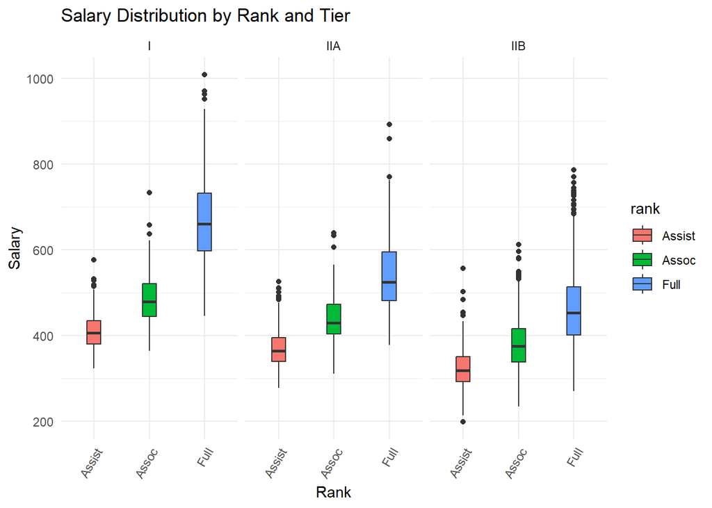

```r
#Using a relative pathway to load the file.
Salaries <- read.csv("./FacultySalaries_1995.csv") %>%
  janitor::clean_names() %>%
  pivot_longer(cols = c("avg_full_prof_salary", "avg_assoc_prof_salary", "avg_assist_prof_salary"),
               names_to = "rank", values_to = "salary") %>%
  mutate(rank = sub("avg_", "", rank), #here I am trying to make it easier to pull the names of each column.
         rank = sub("_prof_salary", "", rank),
         rank = str_to_title(rank))

#I don't need the tier VIIB so this will remove all rows with VIIB so it doesn't show up in the graph.
fixing_tier <- Salaries %>% filter(tier != "VIIB")

#Now I'm making a plot of the salaries by rank and school tier.
ggplot(fixing_tier, aes(x = rank, y = salary, fill = rank)) +
  geom_boxplot(width = 0.25) +
  facet_wrap(~tier) +
  theme_minimal() +
  theme(axis.text.x = element_text(angle = 60, hjust = 1)) +
  labs(title = "Salary Distribution by Rank and Tier", x = "Rank", y = "Salary")
```

In this plot we are able to observe the differing salaries of assistant professors, associate professors and full professors based on the tier of university they work at. We can clearly see that the full professors who work at a tier one school where they focus on research and award PhD degress, make much more compared to those that are at a tier 2B school.

```r
#I am building a linear regression model without interactions
model <- lm(salary ~ state + tier + rank, data = fixing_tier)

#Perform ANOVA
anova_result <- anova(model)

#Display summary
summary(model)
```

```
##
## Call:
## lm(formula = salary ~ state + tier + rank, data = fixing_tier)
##
## Residuals:
##     Min      1Q  Median      3Q     Max
## -206.47  -36.31   -2.13   31.90  329.47
##
## Coefficients:
##             Estimate Std. Error t value Pr(>|t|)
## (Intercept)  474.830     17.612  26.960  < 2e-16 ***
## stateAL      -70.503     18.997  -3.711 0.000210 ***
## stateAR      -55.251     19.613  -2.817 0.004875 **
## stateAZ      -84.749     24.671  -3.435 0.000599 ***
## stateCA       22.567     18.056   1.250 0.211459
## stateCO      -40.960     19.645  -2.085 0.037144 *
## stateCT       37.743     19.513   1.934 0.053163 .
## stateDC       -9.245     21.068  -0.439 0.660808
## stateDE      -17.948     25.176  -0.713 0.475971
## stateFL      -39.752     19.152  -2.076 0.038009 *
## stateGA      -38.424     18.996  -2.023 0.043186 *
## stateHI       35.449     27.548   1.287 0.198237
## stateIA      -36.255     18.793  -1.929 0.053788 .
## stateID      -87.703     23.356  -3.755 0.000176 ***
## stateIL      -31.317     18.145  -1.726 0.084452 .
## stateIN      -44.313     18.300  -2.421 0.015511 *
## stateKS     -103.211     19.293  -5.350 9.41e-08 ***
## stateKY      -68.864     18.987  -3.627 0.000291 ***
## stateLA      -65.740     19.097  -3.442 0.000584 ***
## stateMA       33.907     18.227   1.860 0.062942 .
## stateMD       -9.555     18.974  -0.504 0.614576
## stateME      -24.472     19.880  -1.231 0.218420
## stateMI      -21.459     18.544  -1.157 0.247279
## stateMN      -18.854     18.769  -1.005 0.315207
## stateMO      -61.568     18.484  -3.331 0.000875 ***
## stateMS     -101.578     20.044  -5.068 4.25e-07 ***
## stateMT     -119.917     21.319  -5.625 2.01e-08 ***
## stateNC      -46.821     18.278  -2.562 0.010462 *
## stateND      -84.897     22.740  -3.733 0.000192 ***
## stateNE      -56.407     19.480  -2.896 0.003809 **
```

[output cut: 17 more lines]

```
## stateWA      -39.474     19.641  -2.010 0.044535 *
## stateWI      -37.417     18.674  -2.004 0.045190 *
## stateWV      -79.629     19.638  -4.055 5.13e-05 ***
## stateWY     -112.050     38.987  -2.874 0.004079 **
## tierIIA      -79.331      3.259 -24.345  < 2e-16 ***
## tierIIB     -131.870      3.097 -42.581  < 2e-16 ***
## rankAssoc     63.865      2.537  25.172  < 2e-16 ***
## rankFull     170.794      2.556  66.818  < 2e-16 ***
## ---
## Signif. codes:  0 '***' 0.001 '**' 0.01 '*' 0.05 '.' 0.1 ' ' 1
##
## Residual standard error: 60.3 on 3297 degrees of freedom
##   (128 observations deleted due to missingness)
## Multiple R-squared:  0.7094, Adjusted R-squared:  0.7047
## F-statistic: 149.1 on 54 and 3297 DF,  p-value: < 2.2e-16
```

### Cleaning and Plotting Juniper

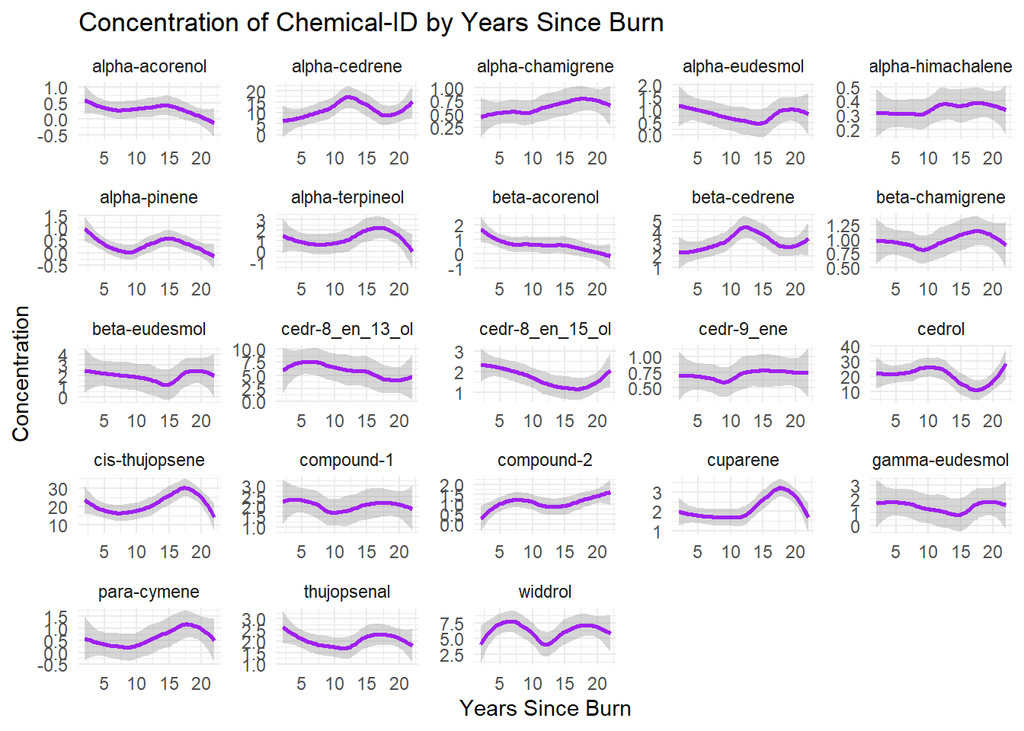

```r
#Lets clean the Juniper data
Juniper <- read.csv("./Juniper_Oils.csv") %>%
  janitor::clean_names() %>%
  pivot_longer(cols = c("alpha_pinene","para_cymene","alpha_terpineol","cedr_9_ene","alpha_cedrene","beta_cedrene","cis_thujopsene","alpha_himachalene","beta_chamigrene","cuparene","compound_1","alpha_chamigrene","widdrol","cedrol","beta_acorenol","alpha_acorenol","gamma_eudesmol","beta_eudesmol","alpha_eudesmol","cedr_8_en_13_ol","cedr_8_en_15_ol","compound_2","thujopsenal"),
               names_to = "chemicalID", values_to = "concentration") %>%
  mutate(chemicalID = sub("_", "-", chemicalID)) #the "clean_names" function adds "_" so I'm trying to replace it with a "-" instead.

#Now im going to plot "years since burn" by "concentration" and facet wrap them by "ChemicalID"
ggplot(data = Juniper, aes(x = years_since_burn, y = concentration)) +
  geom_smooth(method = "loess", scales = "free", color = "purple") +
  labs(title = "Concentration of Chemical-ID by Years Since Burn",
       x = "Years Since Burn",
       y = "Concentration") +
  facet_wrap(~chemicalID, scales = "free") +
  theme_minimal()
```

This plot is unique because it takes data that was part of a collaboration between Young Living inc. and UVU. Some cedar trees were collected after a fire killed them and their chemical composition was taken. This plot shows the concentration of these chemicals in the years since the fire occurred.

### GLM Model

```r
echo = TRUE

#I am making a model that will only show the significant chemicals and their model output
glm_model <- glm(formula = concentration ~ years_since_burn * chemicalID, data = Juniper, family = "gaussian") %>%
  tidy() %>% #using the Broom package
  filter(p.value < 0.05) %>%
  mutate(term = str_remove(term, "chemicalID")) #it keeps adding "chemicalID before the name of every chemical, this is how i'm getting rid of it.

view(glm_model)
```

[output not shown]

Thanks for taking the time to look through my skills test! Hope you liked what you saw.